# Report COVID study NL 212

## 9.2 How does it look if we include a second order latent variable?

**Three-factors model with second order:**

**Visualization of the model**

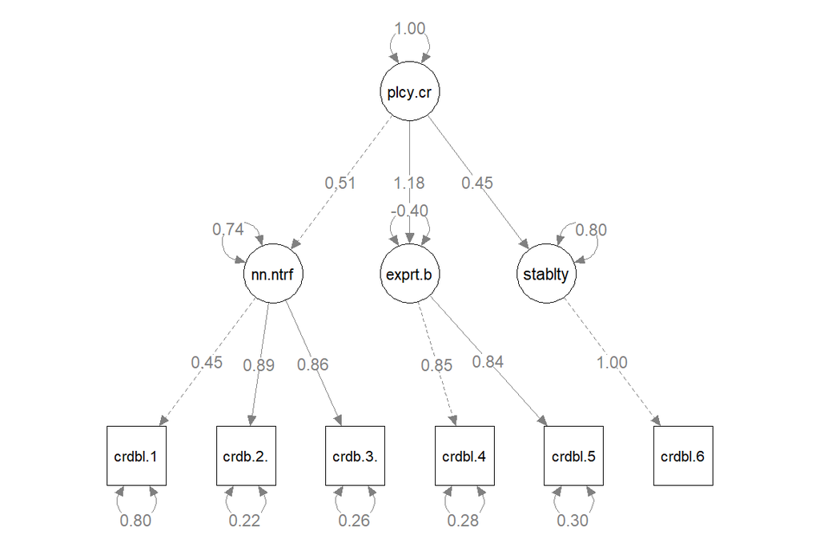

```r
semPaths(fit.3factors.second, "std", weighted = FALSE, nCharNodes = 7, shapeMan = "rectangle",
         sizeMan = 8,  intercepts = FALSE, edge.label.cex = 1, curvePivot = TRUE)
```

**Three-factors model alternative with second order:**

**Visualization of the model**

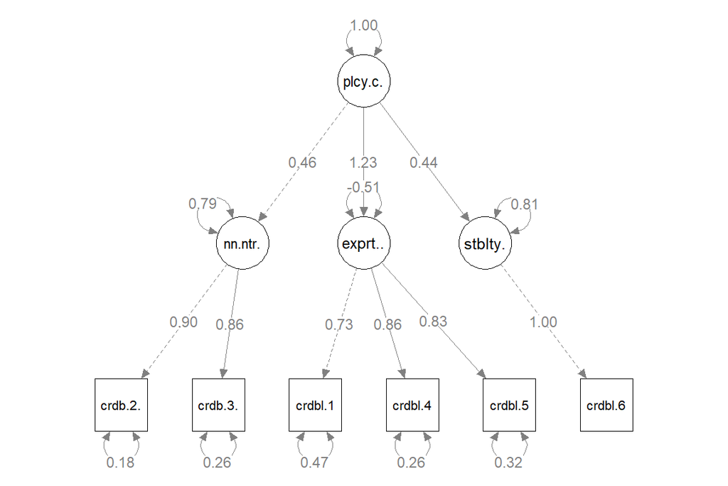

```r
semPaths(fit.3factors.alt.second, "std", weighted = FALSE, nCharNodes = 7, shapeMan = "rectangle",
         sizeMan = 8,  intercepts = FALSE, edge.label.cex = 1, curvePivot = TRUE)
```

In both models, there is an issue with the ‘expert.based’ latent variable, which has negative variance. Further investigation is needed to determine the cause of this problem. Theoretically, it would make sense to add a second order as we expect the three dimensions to be related. That is, we see these dimensions as part of a bigger latent variable (“policy credibility”).

# 10 Regression

## 10.1 Perceived independence

```r
reg.perceived.independence1 <- lm(perceived.independence.reversed ~  trust.politicians + trust.scientist + trust.EC + trust.health.authorities + interpersonal.trust + benefits.vaccines + credibility.EMA + familiarity.EMA + familiarity.advice +  political.ideology + consequences.health + consequences.economic + EU.integration + private.providers + knowledge +  experimental.group + female + poly(age, 2) + healthcare + income + education.recoded,
                    data = df.def,
                    na.action = na.omit)

reg.perceived.independence2 <- lm(perceived.independence.reversed ~ credibility.index + trust.politicians + trust.scientist + trust.EC + trust.health.authorities + interpersonal.trust + benefits.vaccines + credibility.EMA + familiarity.EMA + familiarity.advice +  political.ideology + consequences.health + consequences.economic +  EU.integration + private.providers + knowledge +  experimental.group + female + poly(age, 2) + healthcare + income + education.recoded,
                    data = df.def,
                    na.action = na.omit)


tab_model(reg.perceived.independence1, reg.perceived.independence2,  show.ci = FALSE)
```

|  | perceived independence reversed |  | perceived independence reversed |  |
| --- | --- | --- | --- | --- |
| Predictors | Estimates | p | Estimates | p |
| (Intercept) | 4.31 | **<0.001** | 3.08 | **<0.001** |
| trust.politicians | 0.03 | 0.532 | 0.01 | 0.787 |
| trust.scientist | -0.08 | 0.072 | -0.07 | 0.101 |
| trust.EC | 0.01 | 0.897 | 0.03 | 0.593 |
| trust.health.authorities | -0.02 | 0.601 | -0.12 | **0.002** |
| interpersonal.trust | 0.02 | 0.456 | 0.00 | 0.892 |
| benefits.vaccines | 0.07 | 0.097 | -0.09 | **0.027** |
| credibility.EMA | 0.18 | **<0.001** | 0.08 | 0.092 |
| familiarity.EMA | -0.09 | **0.019** | -0.07 | **0.046** |
| familiarity.advice | -0.04 | 0.335 | -0.06 | 0.063 |
| political.ideology | -0.09 | **0.011** | -0.07 | **0.026** |
| consequences.health | 0.01 | 0.812 | -0.00 | 0.961 |
| consequences.economic | -0.13 | **<0.001** | -0.10 | **<0.001** |
| EU.integration | 0.02 | 0.499 | 0.01 | 0.847 |
| private.providers | -0.12 | **<0.001** | -0.10 | **0.001** |
| knowledge | 0.01 | 0.942 | -0.06 | 0.544 |
| experimental.group [treatment] | 0.19 | **0.035** | 0.17 | **0.041** |
| female | 0.01 | 0.873 | 0.05 | 0.539 |
| age [1st degree] | 2.46 | 0.166 | 0.73 | 0.664 |
| age [2nd degree] | -1.88 | 0.206 | -1.18 | 0.398 |
| healthcare [yes] | -0.17 | 0.264 | -0.10 | 0.481 |
| income20K-25K | -0.00 | 0.986 | -0.06 | 0.661 |
| income25K-30K | -0.06 | 0.725 | -0.12 | 0.464 |
| income30K-35K | -0.07 | 0.678 | -0.15 | 0.343 |
| income35K-40K | 0.07 | 0.689 | 0.03 | 0.868 |
| income40K-45K | -0.24 | 0.183 | -0.28 | 0.097 |
| income45K-50K | -0.05 | 0.776 | -0.12 | 0.501 |
| income [50K>] | 0.10 | 0.536 | 0.02 | 0.908 |
| education.recoded [2. Havo] | 0.21 | 0.278 | 0.23 | 0.216 |
| education.recoded [3. Vwo] | 0.11 | 0.652 | 0.14 | 0.546 |
| education.recoded [4. MBO] | -0.06 | 0.652 | -0.03 | 0.831 |
| education.recoded [5. HBO] | 0.10 | 0.514 | 0.10 | 0.500 |
| education.recoded [6. WO] | 0.08 | 0.665 | 0.05 | 0.766 |
| education.recoded [7. Anders] | 0.14 | 0.689 | 0.09 | 0.783 |
| credibility.index |  |  | 0.63 | **<0.001** |
| Observations | 1015 |  | 1015 |  |
| R<sup>2</sup> / R<sup>2</sup> adjusted | 0.148 / 0.120 |  | 0.243 / 0.217 |  |

## 10.2 Vaccination intension

```r
reg.intent.vaccine1 <- glm(intent.vaccine.recoded ~ trust.politicians + trust.scientist + trust.EC + trust.health.authorities + interpersonal.trust + benefits.vaccines + credibility.EMA + familiarity.EMA + familiarity.advice +  political.ideology + consequences.health + consequences.economic + EU.integration + private.providers + knowledge +  experimental.group + female + age + healthcare + income + education.recoded,
                    data = df.def,
                    na.action = na.omit,
                    family = binomial(link = 'logit'))

reg.intent.vaccine2 <- glm(intent.vaccine.recoded ~ credibility.index + trust.politicians + trust.scientist + trust.EC + trust.health.authorities + interpersonal.trust + benefits.vaccines + credibility.EMA + familiarity.EMA + familiarity.advice +  political.ideology + consequences.health + consequences.economic + EU.integration + private.providers + knowledge +  experimental.group + female + age + healthcare + income + education.recoded,
                    data = df.def,
                    na.action = na.omit,
                    family = binomial(link = 'logit'))

reg.intent.vaccine3 <- glm(intent.vaccine.recoded ~ perceived.independence.reversed + trust.politicians + trust.scientist + trust.EC + trust.health.authorities + interpersonal.trust + benefits.vaccines + credibility.EMA + familiarity.EMA + familiarity.advice +  political.ideology + consequences.health + consequences.economic + EU.integration + private.providers + knowledge +  experimental.group + female + age + healthcare + income + education.recoded,
                    data = df.def,
                    na.action = na.omit,
                    family = binomial(link = 'logit'))

reg.intent.vaccine4 <- glm(intent.vaccine.recoded ~ credibility.index + perceived.independence.reversed + trust.politicians + trust.scientist + trust.EC + trust.health.authorities + interpersonal.trust + benefits.vaccines + credibility.EMA + familiarity.EMA + familiarity.advice +  political.ideology + consequences.health + consequences.economic + EU.integration + private.providers + knowledge +  experimental.group + female + age + healthcare + income + education.recoded,
                    data = df.def,
                    na.action = na.omit,
                    family = binomial(link = 'logit'))

tab_model(reg.intent.vaccine1, reg.intent.vaccine2, reg.intent.vaccine3, reg.intent.vaccine4, show.ci = FALSE)
```

|  | intent vaccine recoded |  | intent vaccine recoded |  | intent vaccine recoded |  | intent vaccine recoded |  |
| --- | --- | --- | --- | --- | --- | --- | --- | --- |
| Predictors | Odds Ratios | p | Odds Ratios | p | Odds Ratios | p | Odds Ratios | p |
| (Intercept) | 0.00 | **<0.001** | 0.00 | **<0.001** | 0.00 | **<0.001** | 0.00 | **<0.001** |
| trust.politicians | 0.81 | 0.067 | 0.81 | 0.058 | 0.79 | **0.036** | 0.79 | **0.038** |
| trust.scientist | 0.98 | 0.848 | 1.00 | 0.975 | 1.06 | 0.631 | 1.07 | 0.605 |
| trust.EC | 1.05 | 0.713 | 1.06 | 0.650 | 1.02 | 0.884 | 1.03 | 0.813 |
| trust.health.authorities | 1.93 | **<0.001** | 1.73 | **<0.001** | 1.97 | **<0.001** | 1.80 | **<0.001** |
| interpersonal.trust | 1.16 | 0.103 | 1.12 | 0.222 | 1.13 | 0.178 | 1.10 | 0.293 |
| benefits.vaccines | 3.34 | **<0.001** | 2.96 | **<0.001** | 3.41 | **<0.001** | 3.08 | **<0.001** |
| credibility.EMA | 0.86 | 0.209 | 0.81 | 0.078 | 0.84 | 0.155 | 0.81 | 0.076 |
| familiarity.EMA | 1.07 | 0.544 | 1.11 | 0.326 | 1.09 | 0.434 | 1.13 | 0.273 |
| familiarity.advice | 1.01 | 0.927 | 0.97 | 0.768 | 1.05 | 0.614 | 1.01 | 0.894 |
| political.ideology | 0.92 | 0.446 | 0.93 | 0.480 | 0.96 | 0.691 | 0.96 | 0.711 |
| consequences.health | 1.16 | 0.088 | 1.16 | 0.093 | 1.15 | 0.105 | 1.16 | 0.108 |
| consequences.economic | 1.05 | 0.514 | 1.06 | 0.474 | 1.08 | 0.305 | 1.08 | 0.311 |
| EU.integration | 1.27 | **0.018** | 1.26 | **0.024** | 1.30 | **0.011** | 1.28 | **0.017** |
| private.providers | 0.96 | 0.690 | 0.96 | 0.656 | 1.02 | 0.869 | 1.00 | 0.972 |
| knowledge | 1.42 | 0.147 | 1.34 | 0.230 | 1.38 | 0.191 | 1.31 | 0.270 |
| experimental.group [treatment] | 1.18 | 0.474 | 1.23 | 0.383 | 1.12 | 0.627 | 1.16 | 0.528 |
| female | 0.99 | 0.962 | 1.02 | 0.943 | 0.94 | 0.803 | 0.97 | 0.899 |
| age | 1.05 | **<0.001** | 1.05 | **<0.001** | 1.06 | **<0.001** | 1.06 | **<0.001** |
| healthcare [yes] | 0.59 | 0.134 | 0.65 | 0.244 | 0.63 | 0.196 | 0.68 | 0.292 |
| income20K-25K | 0.95 | 0.909 | 0.82 | 0.626 | 0.93 | 0.862 | 0.80 | 0.586 |
| income25K-30K | 0.83 | 0.672 | 0.79 | 0.595 | 0.78 | 0.563 | 0.74 | 0.506 |
| income30K-35K | 1.14 | 0.735 | 1.03 | 0.943 | 1.10 | 0.817 | 0.99 | 0.973 |
| income35K-40K | 1.57 | 0.324 | 1.41 | 0.451 | 1.37 | 0.489 | 1.25 | 0.631 |
| income40K-45K | 1.71 | 0.251 | 1.58 | 0.336 | 1.74 | 0.246 | 1.62 | 0.318 |
| income45K-50K | 0.97 | 0.951 | 0.87 | 0.757 | 1.02 | 0.967 | 0.91 | 0.837 |
| income [50K>] | 2.04 | 0.076 | 1.81 | 0.146 | 1.99 | 0.093 | 1.76 | 0.173 |
| education.recoded [2. Havo] | 1.20 | 0.722 | 1.33 | 0.594 | 1.14 | 0.804 | 1.25 | 0.678 |
| education.recoded [3. Vwo] | 2.05 | 0.290 | 2.39 | 0.208 | 2.07 | 0.291 | 2.40 | 0.211 |
| education.recoded [4. MBO] | 1.66 | 0.135 | 1.84 | 0.078 | 1.71 | 0.120 | 1.88 | 0.071 |
| education.recoded [5. HBO] | 1.91 | 0.135 | 2.19 | 0.075 | 1.93 | 0.135 | 2.16 | 0.084 |
| education.recoded [6. WO] | 1.99 | 0.209 | 2.18 | 0.170 | 2.25 | 0.148 | 2.41 | 0.130 |
| education.recoded [7. Anders] | 1.50 | 0.603 | 1.56 | 0.582 | 1.44 | 0.656 | 1.45 | 0.657 |
| credibility.index |  |  | 1.88 | **<0.001** |  |  | 1.74 | **0.003** |
| perceived.independence.reversed |  |  |  |  | 1.48 | **<0.001** | 1.42 | **0.001** |
| Observations | 1015 |  | 1015 |  | 1015 |  | 1015 |  |
| R<sup>2</sup> Tjur | 0.576 |  | 0.586 |  | 0.587 |  | 0.594 |  |

## 10.3 Crebility of EMA’s decision

```r
reg.credibility1 <- lm(credibility.index  ~ trust.politicians + trust.scientist + trust.EC + trust.health.authorities + interpersonal.trust + benefits.vaccines + credibility.EMA + familiarity.EMA + familiarity.advice + political.ideology + consequences.health + consequences.economic + EU.integration + private.providers + knowledge +  experimental.group + female + poly(age, 2) + healthcare + income + education.recoded,
                    data = df.def,
                    na.action = na.omit)

reg.credibility2 <- lm(credibility.index  ~ perceived.independence.reversed + trust.politicians + trust.scientist + trust.EC + trust.health.authorities + interpersonal.trust + benefits.vaccines + credibility.EMA + familiarity.EMA + familiarity.advice +  political.ideology + consequences.health + consequences.economic + EU.integration + private.providers + knowledge +  experimental.group + female + poly(age, 2) + healthcare + income + education.recoded,
                    data = df.def,
                    na.action = na.omit)

reg.credibility3 <- lm(credibility.index  ~ perceived.independence.reversed + trust.politicians + trust.scientist + trust.EC + trust.health.authorities + interpersonal.trust + benefits.vaccines + credibility.EMA + familiarity.EMA +  + familiarity.advice +  political.ideology + consequences.health + consequences.economic + EU.integration + private.providers + knowledge +  experimental.group + female + poly(age, 2) + healthcare + income + education.recoded + perceived.independence.reversed:benefits.vaccines + benefits.vaccines:experimental.group,
                    data = df.def,
                    na.action = na.omit)

reg.credibility4 <- lm(credibility.index  ~ perceived.independence.reversed + trust.politicians + trust.scientist + trust.EC + trust.health.authorities + interpersonal.trust + benefits.vaccines + credibility.EMA + familiarity.EMA +  + familiarity.advice +  political.ideology + consequences.health + consequences.economic + EU.integration + private.providers + knowledge +  experimental.group + female + age.recoded + healthcare + income + education.recoded + perceived.independence.reversed:benefits.vaccines + benefits.vaccines:experimental.group,
                    data = df.def,
                    na.action = na.omit)


reg.credibility3.centered <- meanCenter(reg.credibility3, centerOnlyInteractors = TRUE, centerDV = FALSE)

reg.credibility4.centered <- meanCenter(reg.credibility4, centerOnlyInteractors = TRUE, centerDV = FALSE)

tab_model(reg.credibility1, reg.credibility2, reg.credibility3.centered, show.ci = FALSE)
```

|  | credibility index |  | credibility index |  | credibility index |  |
| --- | --- | --- | --- | --- | --- | --- |
| Predictors | Estimates | p | Estimates | p | Estimates | p |
| (Intercept) | 1.94 | **<0.001** | 1.18 | **<0.001** | 3.01 | **<0.001** |
| trust.politicians | 0.02 | 0.267 | 0.02 | 0.340 | 0.02 | 0.399 |
| trust.scientist | -0.02 | 0.446 | -0.00 | 0.865 | -0.01 | 0.622 |
| trust.EC | -0.03 | 0.261 | -0.03 | 0.216 | -0.03 | 0.212 |
| trust.health.authorities | 0.16 | **<0.001** | 0.16 | **<0.001** | 0.16 | **<0.001** |
| interpersonal.trust | 0.03 | 0.065 | 0.03 | 0.090 | 0.03 | 0.108 |
| benefits.vaccines | 0.25 | **<0.001** | 0.24 | **<0.001** |  |  |
| credibility.EMA | 0.16 | **<0.001** | 0.13 | **<0.001** | 0.13 | **<0.001** |
| familiarity.EMA | -0.03 | 0.163 | -0.01 | 0.519 | -0.01 | 0.542 |
| familiarity.advice | 0.05 | **0.017** | 0.05 | **0.004** | 0.04 | **0.029** |
| political.ideology | -0.03 | 0.179 | -0.01 | 0.602 | -0.01 | 0.613 |
| consequences.health | 0.01 | 0.396 | 0.01 | 0.414 | 0.02 | 0.287 |
| consequences.economic | -0.04 | **0.003** | -0.02 | 0.148 | -0.02 | 0.197 |
| EU.integration | 0.03 | 0.139 | 0.02 | 0.184 | 0.03 | 0.106 |
| private.providers | -0.04 | **0.025** | -0.02 | 0.325 | -0.01 | 0.446 |
| knowledge | 0.10 | 0.053 | 0.10 | **0.043** | 0.10 | **0.041** |
| experimental.group [treatment] | 0.03 | 0.586 | -0.01 | 0.866 | -0.02 | 0.644 |
| female | -0.06 | 0.209 | -0.06 | 0.165 | -0.05 | 0.243 |
| age [1st degree] | 2.73 | **0.004** | 2.30 | **0.009** | 2.12 | **0.016** |
| age [2nd degree] | -1.09 | 0.162 | -0.76 | 0.301 | -0.70 | 0.334 |
| healthcare [yes] | -0.11 | 0.177 | -0.08 | 0.300 | -0.07 | 0.321 |
| income20K-25K | 0.10 | 0.236 | 0.10 | 0.207 | 0.11 | 0.160 |
| income25K-30K | 0.09 | 0.311 | 0.10 | 0.231 | 0.11 | 0.187 |
| income30K-35K | 0.12 | 0.151 | 0.14 | 0.095 | 0.14 | 0.077 |
| income35K-40K | 0.06 | 0.466 | 0.05 | 0.528 | 0.07 | 0.420 |
| income40K-45K | 0.06 | 0.485 | 0.11 | 0.226 | 0.12 | 0.182 |
| income45K-50K | 0.11 | 0.293 | 0.12 | 0.224 | 0.11 | 0.232 |
| income [50K>] | 0.12 | 0.127 | 0.11 | 0.161 | 0.10 | 0.194 |
| education.recoded [2. Havo] | -0.03 | 0.807 | -0.06 | 0.520 | -0.05 | 0.577 |
| education.recoded [3. Vwo] | -0.05 | 0.721 | -0.07 | 0.590 | -0.02 | 0.859 |
| education.recoded [4. MBO] | -0.05 | 0.454 | -0.04 | 0.526 | -0.02 | 0.738 |
| education.recoded [5. HBO] | 0.00 | 0.962 | -0.01 | 0.857 | 0.00 | 1.000 |
| education.recoded [6. WO] | 0.05 | 0.648 | 0.03 | 0.741 | 0.04 | 0.685 |
| education.recoded [7. Anders] | 0.08 | 0.676 | 0.05 | 0.763 | 0.00 | 0.990 |
| perceived.independence.reversed |  |  | 0.18 | **<0.001** |  |  |
| perceived.independence.reversedc |  |  |  |  | 0.17 | **<0.001** |
| benefits.vaccinesc |  |  |  |  | 0.23 | **<0.001** |
| perceived.independence.reversedc * benefits.vaccinesc |  |  |  |  | 0.04 | **<0.001** |
| benefits.vaccinesc * experimental.group [treatment] |  |  |  |  | 0.05 | 0.095 |
| Observations | 1015 |  | 1015 |  | 1015 |  |
| R<sup>2</sup> / R<sup>2</sup> adjusted | 0.594 / 0.580 |  | 0.639 / 0.627 |  | 0.647 / 0.634 |  |

*Note: Interaction variables are centered in the third model*

### 10.3.1 Plots

*Interaction effect: perceived independence x benefits of vaccines*

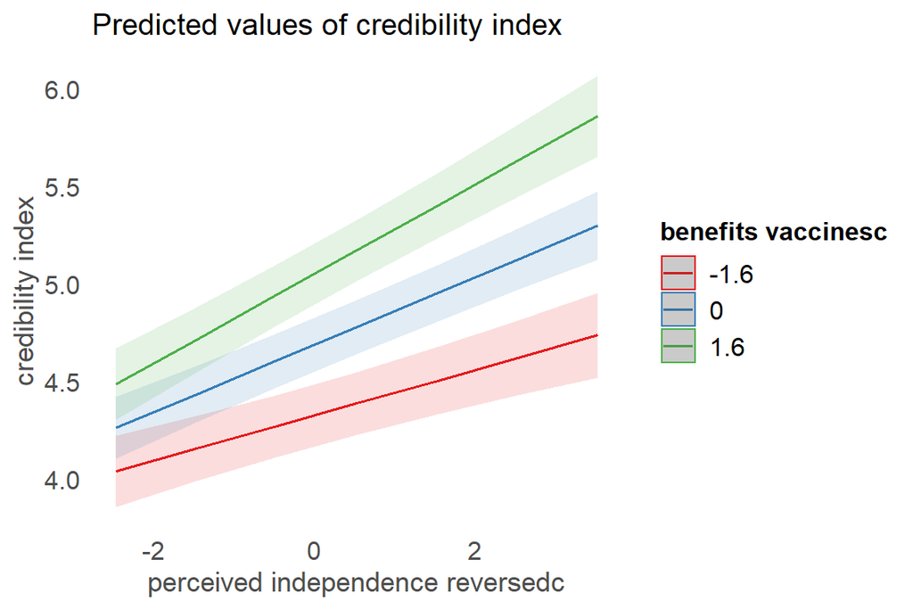

```r
plot_model(reg.credibility3.centered, type = "int", mdrt.values = "meansd")[[1]]
```

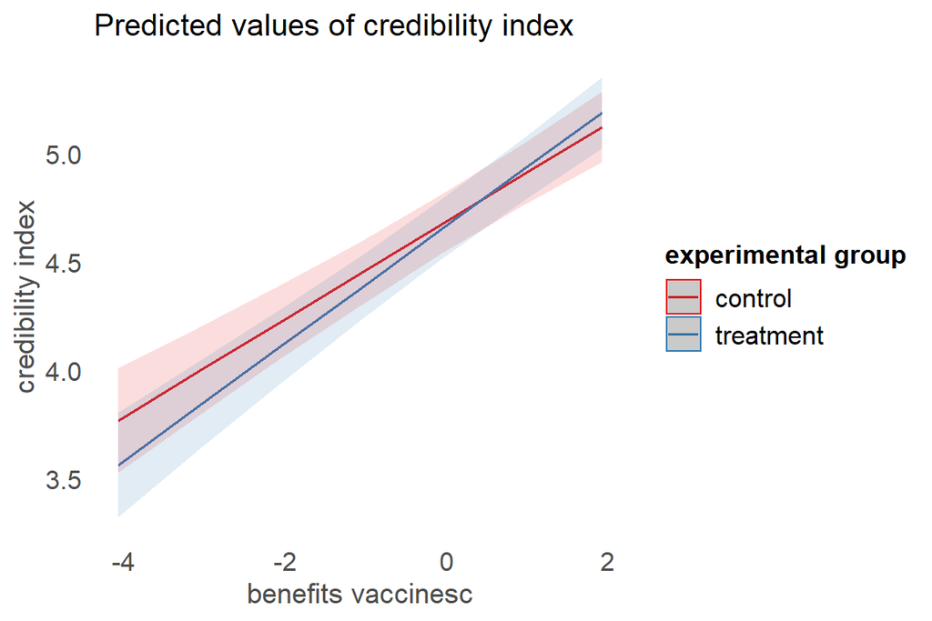

```r
plot_model(reg.credibility3.centered, type = "int", mdrt.values = "meansd")[[2]]
```

*marginal effects: Effect of perceived independence on credibility for different age groups*

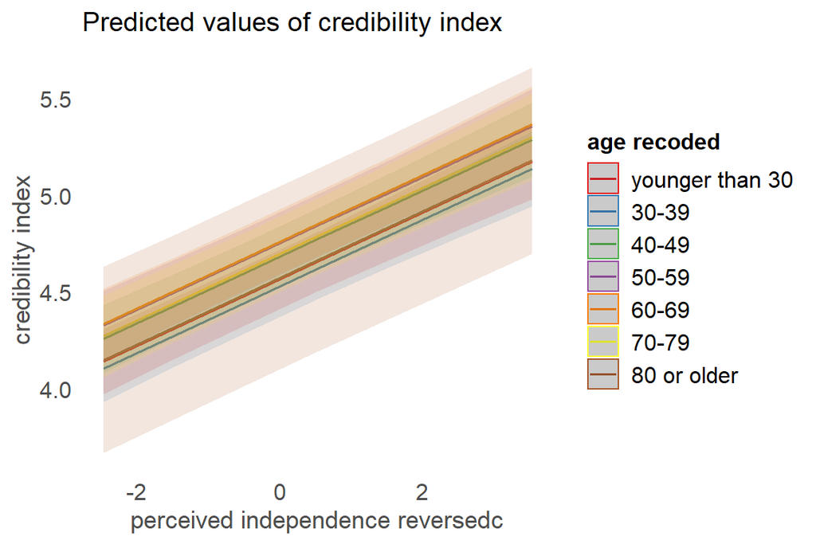

```r
plot_model(reg.credibility4.centered, type = "pred", terms = c("perceived.independence.reversedc", "age.recoded"))
```

## 10.4 Full models - filtered

### 10.4.1 Perceived independence

```r
reg.perceived.independence.30 <- lm(perceived.independence.reversed ~ credibility.index + trust.politicians + trust.scientist + trust.EC + trust.health.authorities + interpersonal.trust + benefits.vaccines + credibility.EMA + familiarity.EMA + familiarity.advice +  political.ideology + consequences.health + consequences.economic +  EU.integration + private.providers + knowledge +  experimental.group + female + poly(age, 2) + healthcare + income + education.recoded,
                    data = df.30,
                    na.action = na.omit)

reg.perceived.independence.check <- lm(perceived.independence.reversed ~ credibility.index + trust.politicians + trust.scientist + trust.EC + trust.health.authorities + interpersonal.trust + benefits.vaccines + credibility.EMA + familiarity.EMA + familiarity.advice +  political.ideology + consequences.health + consequences.economic +  EU.integration + private.providers + knowledge +  experimental.group + female + poly(age, 2) + healthcare + income + education.recoded,
                    data = df.check,
                    na.action = na.omit)

tab_model(reg.perceived.independence.30, reg.perceived.independence.check, dv.labels = c("Perceived independence (filter = page submission)", "Perceived independence (filter = manipulation check)"), show.ci = FALSE)
```

|  | Perceived independence (filter = page submission) |  | Perceived independence (filter = manipulation check) |  |
| --- | --- | --- | --- | --- |
| Predictors | Estimates | p | Estimates | p |
| (Intercept) | 1.34 | **0.045** | 2.69 | **<0.001** |
| credibility.index | 0.78 | **<0.001** | 0.73 | **<0.001** |
| trust.politicians | -0.02 | 0.788 | -0.03 | 0.642 |
| trust.scientist | -0.15 | 0.059 | -0.09 | 0.135 |
| trust.EC | 0.02 | 0.831 | 0.03 | 0.596 |
| trust.health.authorities | -0.11 | 0.112 | -0.07 | 0.152 |
| interpersonal.trust | 0.12 | **0.019** | -0.01 | 0.874 |
| benefits.vaccines | -0.01 | 0.915 | -0.16 | **0.004** |
| credibility.EMA | 0.04 | 0.593 | 0.08 | 0.145 |
| familiarity.EMA | 0.02 | 0.796 | -0.03 | 0.529 |
| familiarity.advice | -0.02 | 0.677 | -0.05 | 0.306 |
| political.ideology | -0.08 | 0.168 | -0.06 | 0.130 |
| consequences.health | 0.03 | 0.646 | -0.02 | 0.688 |
| consequences.economic | -0.07 | 0.133 | -0.10 | **0.003** |
| EU.integration | 0.01 | 0.853 | 0.01 | 0.890 |
| private.providers | -0.01 | 0.892 | -0.10 | **0.006** |
| knowledge | -0.40 | **0.021** | -0.02 | 0.869 |
| experimental.group [treatment] | 0.26 | 0.093 | 0.27 | **0.013** |
| female | 0.13 | 0.406 | -0.04 | 0.746 |
| age [1st degree] | -1.35 | 0.431 | -0.19 | 0.910 |
| age [2nd degree] | -0.39 | 0.788 | -0.00 | 0.999 |
| healthcare [yes] | -0.73 | **0.007** | -0.03 | 0.888 |
| income20K-25K | 0.04 | 0.860 | 0.08 | 0.657 |
| income25K-30K | -0.28 | 0.350 | -0.08 | 0.710 |
| income30K-35K | -0.45 | 0.095 | -0.20 | 0.330 |
| income35K-40K | -0.03 | 0.899 | -0.06 | 0.756 |
| income40K-45K | 0.01 | 0.977 | -0.23 | 0.316 |
| income45K-50K | 0.09 | 0.783 | -0.13 | 0.575 |
| income [50K>] | -0.06 | 0.837 | 0.08 | 0.666 |
| education.recoded [2. Havo] | -0.23 | 0.477 | 0.13 | 0.594 |
| education.recoded [3. Vwo] | -0.96 | 0.088 | -0.10 | 0.788 |
| education.recoded [4. MBO] | -0.08 | 0.709 | -0.09 | 0.594 |
| education.recoded [5. HBO] | -0.15 | 0.578 | -0.06 | 0.743 |
| education.recoded [6. WO] | -0.04 | 0.907 | 0.12 | 0.599 |
| education.recoded [7. Anders] | -0.29 | 0.685 | 0.38 | 0.462 |
| Observations | 337 |  | 632 |  |
| R<sup>2</sup> / R<sup>2</sup> adjusted | 0.352 / 0.279 |  | 0.276 / 0.234 |  |

### 10.4.2 Vaccination intention

```r
reg.intent.vaccine.30 <- glm(intent.vaccine.recoded ~ credibility.index + perceived.independence.reversed + trust.politicians + trust.scientist + trust.EC + trust.health.authorities + interpersonal.trust + benefits.vaccines + credibility.EMA + familiarity.EMA + familiarity.advice +  political.ideology + consequences.health + consequences.economic + EU.integration + private.providers + knowledge +  experimental.group + female + age + healthcare + income + education.recoded,
                    data = df.30,
                    na.action = na.omit,
                    family = binomial(link = 'logit'))

reg.intent.vaccine.check  <- glm(intent.vaccine.recoded ~ credibility.index + perceived.independence.reversed + trust.politicians + trust.scientist + trust.EC + trust.health.authorities + interpersonal.trust + benefits.vaccines + credibility.EMA + familiarity.EMA + familiarity.advice +  political.ideology + consequences.health + consequences.economic + EU.integration + private.providers + knowledge +  experimental.group + female + age + healthcare + income + education.recoded,
                    data = df.check,
                    na.action = na.omit,
                    family = binomial(link = 'logit'))

tab_model(reg.intent.vaccine.30, reg.intent.vaccine.check, dv.labels = c("Vaccination intention (filter = page submission)", "Vaccination intention (filter = manipulation check)"), show.ci = FALSE)
```

|  | Vaccination intention (filter = page submission) |  | Vaccination intention (filter = manipulation check) |  |
| --- | --- | --- | --- | --- |
| Predictors | Odds Ratios | p | Odds Ratios | p |
| (Intercept) | 0.00 | **<0.001** | 0.00 | **<0.001** |
| credibility.index | 4.45 | **0.001** | 2.41 | **<0.001** |
| perceived.independence.reversed | 0.83 | 0.434 | 1.15 | 0.298 |
| trust.politicians | 0.63 | 0.129 | 0.82 | 0.170 |
| trust.scientist | 1.21 | 0.496 | 1.26 | 0.163 |
| trust.EC | 1.49 | 0.248 | 0.99 | 0.966 |
| trust.health.authorities | 1.52 | 0.103 | 1.53 | **0.004** |
| interpersonal.trust | 1.27 | 0.257 | 1.12 | 0.347 |
| benefits.vaccines | 5.97 | **<0.001** | 3.08 | **<0.001** |
| credibility.EMA | 0.71 | 0.282 | 0.72 | **0.035** |
| familiarity.EMA | 1.49 | 0.114 | 1.33 | **0.044** |
| familiarity.advice | 0.86 | 0.492 | 0.92 | 0.507 |
| political.ideology | 1.32 | 0.235 | 0.95 | 0.682 |
| consequences.health | 1.31 | 0.196 | 1.11 | 0.395 |
| consequences.economic | 1.47 | **0.039** | 1.08 | 0.420 |
| EU.integration | 1.58 | **0.049** | 1.36 | **0.015** |
| private.providers | 1.03 | 0.894 | 0.93 | 0.576 |
| knowledge | 0.56 | 0.388 | 1.06 | 0.868 |
| experimental.group [treatment] | 1.49 | 0.512 | 1.34 | 0.371 |
| female | 0.83 | 0.771 | 1.39 | 0.350 |
| age | 1.07 | **0.009** | 1.06 | **<0.001** |
| healthcare [yes] | 1.33 | 0.824 | 0.94 | 0.902 |
| income20K-25K | 1.20 | 0.846 | 0.99 | 0.984 |
| income25K-30K | 1.59 | 0.683 | 0.64 | 0.448 |
| income30K-35K | 2.31 | 0.381 | 1.08 | 0.888 |
| income35K-40K | 5.11 | 0.258 | 1.44 | 0.574 |
| income40K-45K | 3.26 | 0.311 | 1.47 | 0.555 |
| income45K-50K | 1.58 | 0.698 | 0.81 | 0.724 |
| income [50K>] | 0.85 | 0.871 | 1.72 | 0.318 |
| education.recoded [2. Havo] | 0.18 | 0.203 | 0.62 | 0.496 |
| education.recoded [3. Vwo] | 0.91 | 0.968 | 2.11 | 0.464 |
| education.recoded [4. MBO] | 1.47 | 0.636 | 1.30 | 0.557 |
| education.recoded [5. HBO] | 6.00 | 0.110 | 1.30 | 0.629 |
| education.recoded [6. WO] | 1.12 | 0.935 | 4.54 | 0.054 |
| education.recoded [7. Anders] | 0.14 | 0.292 | 5.70 | 0.323 |
| Observations | 337 |  | 632 |  |
| R<sup>2</sup> Tjur | 0.718 |  | 0.610 |  |

### 10.4.3 Credibility index

```r
reg.credibility.30 <- lm(credibility.index  ~ perceived.independence.reversed + trust.politicians + trust.scientist + trust.EC + trust.health.authorities + interpersonal.trust + benefits.vaccines + credibility.EMA + familiarity.EMA +  familiarity.advice +  political.ideology + consequences.health + consequences.economic + EU.integration + private.providers + knowledge +  experimental.group + female + poly(age, 2) + healthcare + income + education.recoded + perceived.independence.reversed:benefits.vaccines + benefits.vaccines:experimental.group,
                    data = df.30,
                    na.action = na.omit)

reg.credibility.check <- lm(credibility.index  ~ perceived.independence.reversed + trust.politicians + trust.scientist + trust.EC + trust.health.authorities + interpersonal.trust + benefits.vaccines + credibility.EMA + familiarity.EMA +  + familiarity.advice +  political.ideology + consequences.health + consequences.economic + EU.integration + private.providers + knowledge +  experimental.group + female + poly(age, 2) + healthcare + income + education.recoded + perceived.independence.reversed:benefits.vaccines + benefits.vaccines:experimental.group,
                    data = df.check,
                    na.action = na.omit)

tab_model(reg.credibility.30, reg.credibility.check, dv.labels = c("Credibility (filter = page submission)",  "Credibility (filter = manipulation check)"), show.ci = FALSE)
```

|  | Credibility (filter = page submission) |  | Credibility (filter = manipulation check) |  |
| --- | --- | --- | --- | --- |
| Predictors | Estimates | p | Estimates | p |
| (Intercept) | 1.14 | **0.006** | 1.38 | **<0.001** |
| perceived.independence.reversed | 0.15 | 0.058 | 0.09 | 0.123 |
| trust.politicians | 0.03 | 0.434 | 0.05 | 0.106 |
| trust.scientist | -0.01 | 0.889 | 0.03 | 0.271 |
| trust.EC | 0.01 | 0.820 | -0.04 | 0.179 |
| trust.health.authorities | 0.21 | **<0.001** | 0.14 | **<0.001** |
| interpersonal.trust | -0.04 | 0.094 | 0.02 | 0.228 |
| benefits.vaccines | 0.23 | **<0.001** | 0.17 | **<0.001** |
| credibility.EMA | 0.10 | **0.012** | 0.11 | **<0.001** |
| familiarity.EMA | 0.01 | 0.707 | -0.04 | 0.101 |
| familiarity.advice | 0.05 | 0.091 | 0.05 | **0.041** |
| political.ideology | -0.01 | 0.669 | 0.00 | 0.873 |
| consequences.health | 0.01 | 0.824 | 0.01 | 0.643 |
| consequences.economic | -0.02 | 0.517 | -0.01 | 0.595 |
| EU.integration | 0.01 | 0.700 | 0.05 | **0.043** |
| private.providers | -0.02 | 0.381 | -0.01 | 0.630 |
| knowledge | 0.17 | **0.040** | 0.08 | 0.198 |
| experimental.group [treatment] | 0.22 | 0.381 | -0.19 | 0.313 |
| female | -0.14 | 0.076 | -0.02 | 0.778 |
| age [1st degree] | 1.36 | 0.108 | 1.46 | 0.093 |
| age [2nd degree] | -0.76 | 0.284 | -0.30 | 0.678 |
| healthcare [yes] | 0.09 | 0.482 | -0.16 | 0.087 |
| income20K-25K | 0.02 | 0.892 | 0.11 | 0.255 |
| income25K-30K | 0.19 | 0.181 | 0.13 | 0.230 |
| income30K-35K | 0.33 | **0.012** | 0.14 | 0.174 |
| income35K-40K | 0.00 | 0.976 | 0.09 | 0.390 |
| income40K-45K | 0.03 | 0.863 | 0.13 | 0.269 |
| income45K-50K | 0.11 | 0.481 | 0.13 | 0.244 |
| income [50K>] | 0.23 | 0.086 | 0.10 | 0.312 |
| education.recoded [2. Havo] | 0.13 | 0.415 | -0.05 | 0.713 |
| education.recoded [3. Vwo] | 0.05 | 0.868 | -0.13 | 0.474 |
| education.recoded [4. MBO] | 0.01 | 0.924 | -0.02 | 0.762 |
| education.recoded [5. HBO] | 0.02 | 0.882 | 0.03 | 0.769 |
| education.recoded [6. WO] | 0.17 | 0.282 | -0.06 | 0.581 |
| education.recoded [7. Anders] | 0.17 | 0.629 | 0.14 | 0.592 |
| perceived.independence.reversed * benefits.vaccines | 0.01 | 0.583 | 0.02 | 0.051 |
| benefits.vaccines * experimental.group [treatment] | -0.03 | 0.507 | 0.03 | 0.353 |
| Observations | 337 |  | 632 |  |
| R<sup>2</sup> / R<sup>2</sup> adjusted | 0.749 / 0.719 |  | 0.675 / 0.655 |  |

# 11 Familiarity

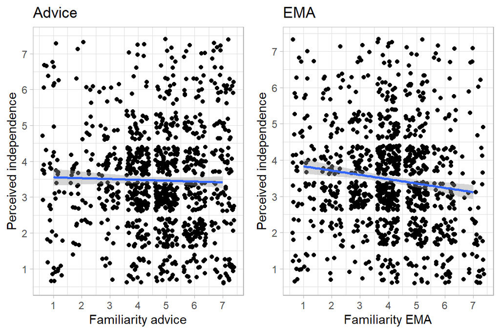

```r
p15 <-  df.def %>% ggplot(aes(familiarity.advice, perceived.independence.reversed)) + geom_jitter() + geom_smooth(method = "lm") + scale_x_continuous("Familiarity advice", breaks = 1:7) + scale_y_continuous("Perceived independence", breaks = 1:7) + labs(title = "Advice") + theme_light()

p16 <-  df.def %>% ggplot(aes(familiarity.EMA, perceived.independence.reversed)) + geom_jitter() + geom_smooth(method = "lm") + scale_x_continuous("Familiarity EMA", breaks = 1:7) + scale_y_continuous("Perceived independence", breaks = 1:7) + labs(title = "EMA") + theme_light()

ggarrange(p15, p16,
          ncol = 2,nrow = 1)
```

# 12 Remarks from participants

```r
df.total %>%
  filter(nchar(comments.general)>1) %>%
  select(comments.general) %>%
  kable() %>%
  kable_styling(bootstrap_options = "striped", full_width = F) %>%    scroll_box(height = "400px")
```

[output not shown]